# GA Education Analysis

Ethan Shen

6/8/2020

This project seeks to predict the average graduation rate of high schools in each county in GA.

# Data

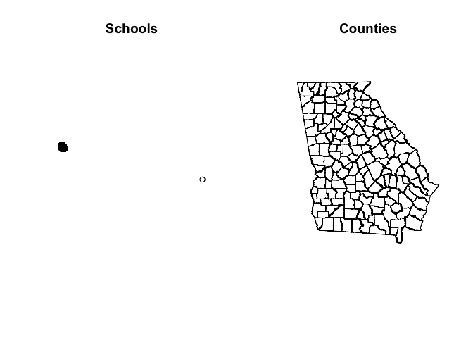

```r
init_schools = st_read("data/schools_2009/DOE Schools 2009.shp", quiet=T)
init_counties = st_read("data/Counties_Georgia-shp/Counties_Georgia.shp", quiet=T)
school_names = read_csv("data/school-19.csv")

par(mfrow = c(1,2))
plot(st_geometry(init_schools), main="Schools")
plot(st_geometry(init_counties), main="Counties")
```

The `schools` dataset has some schools which are not in GA. We fix that issue first.

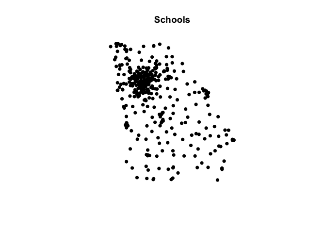

```r
schools = st_intersection(init_schools %>%
                            st_transform(st_crs(init_counties)),
                          init_counties
) %>%
  filter(GRADES == "09,10,11,12")
plot(st_geometry(schools), pch=16, main="Schools")
```

This looks like the shape of GA.

```r
schools_data = inner_join(init_schools, school_names, by = c("SCHOOLNAME" = "SchoolName"))

counties_data = inner_join(init_counties, school_names, by = c("NAMELSAD10" = "SystemName"))
```

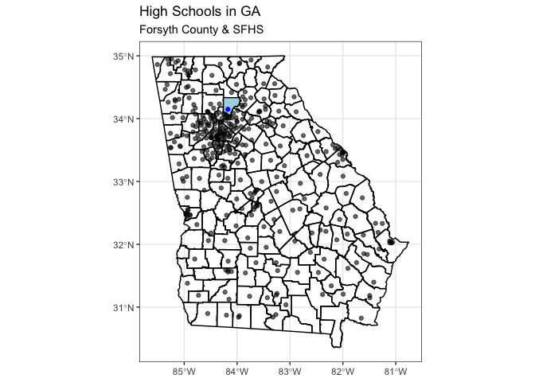

```r
ggplot() +
  geom_sf(data = schools, alpha=0.6) +
  geom_sf(data = init_counties, fill=NA, col="black") +
  geom_sf(data = init_counties %>% filter(NAME10 == "Forsyth"), fill = "lightblue", col="black") +
  geom_sf(data = schools %>% filter(SCHOOLNAME == "South Forsyth High School"), color = "blue") +
  labs(title = "High Schools in GA",
       subtitle = "Forsyth County & SFHS")
```

## Wrangling Data

I am only select data that is pertinent to a school’s demographic and other variables that are relevant to a high school’s performance. Then, I am calculating the average graduation rate for each county.

```r
grad_rate = counties_data %>%
  # filter(Grades %in%
  #          counties_data$Grades[str_detect(counties_data$Grades, "12")]) %>%
  # filter(Grades=="9-12") %>%
  select(NAME10, total_enroll, SingleScore:pct_lep, Graduation_RateH,  English_BegH:Four_Year_Graduation_Rate, FinancialEfficiency:geometry) %>%
  #select(NAME10, Graduation_RateH, Accelerated_Course_Taking, geometry) %>%
  mutate_if(is.character, as.numeric) %>%
  group_by(NAME10) %>%
  summarise_if(is.numeric, mean, na.rm=TRUE) %>%
  filter(!is.na(Graduation_RateH))
```

# EDA

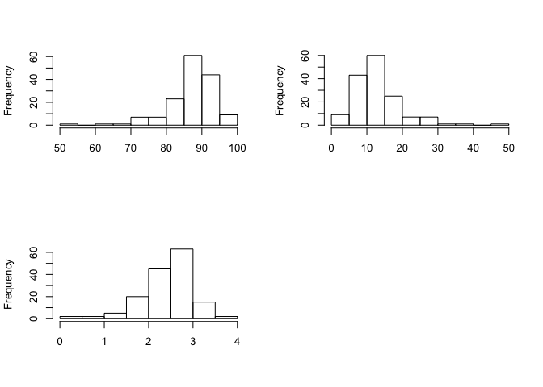

```r
par(mfrow=c(2,2))
hist(grad_rate$Graduation_RateH, main="", xlab="")
hist(max(grad_rate$Graduation_RateH) + 1 - grad_rate$Graduation_RateH, main="", xlab="")
hist(log(max(grad_rate$Graduation_RateH) + 1 - grad_rate$Graduation_RateH), main="", xlab="")
```

It seems like the last transformation looks the most “normal”. I will use the transformed version, `Graduation_RateH_transformed`, in my analysis.

```r
grad_rate = grad_rate %>%
  mutate(Graduation_RateH_transformed = log(max(grad_rate$Graduation_RateH) + 1 - grad_rate$Graduation_RateH))
```

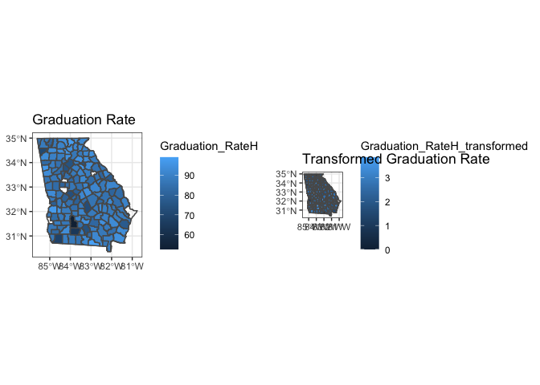

```r
gridExtra::grid.arrange(
  ggplot() +
    geom_sf(data=init_counties, fill=NA) +
    geom_sf(data = grad_rate, aes(fill=Graduation_RateH)) +
    scale_fill_continuous(na.value="white") +
    labs(title = "Graduation Rate"),
  ggplot() +
    geom_sf(data=init_counties, fill=NA) +
    geom_sf(data = grad_rate, aes(fill=Graduation_RateH_transformed)) +
    scale_fill_continuous(na.value="white") +
    labs(title = "Transformed Graduation Rate"),
  ncol=2)
```

## Creating Weight Matrix

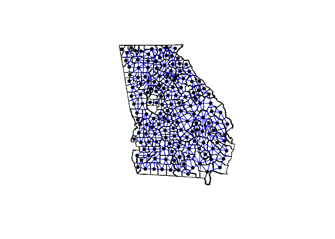

```r
W = st_touches(grad_rate, sparse = FALSE)
listW = mat2listw(W)

plot(st_geometry(grad_rate))
plot(listW, st_geometry(st_centroid(grad_rate)), pch=16, col="blue", add=TRUE)
```

## Moran’s and Geary’s

```r
moran.test(grad_rate$Graduation_RateH_transformed, listW)
```

```
##
##  Moran I test under randomisation
##
## data:  grad_rate$Graduation_RateH_transformed
## weights: listW
##
## Moran I statistic standard deviate = 3.2462, p-value = 0.0005848
## alternative hypothesis: greater
## sample estimates:
## Moran I statistic       Expectation          Variance
##       0.150152726      -0.006535948       0.002329828
```

```r
geary.test(grad_rate$Graduation_RateH_transformed, listW)
```

```
##
##  Geary C test under randomisation
##
## data:  grad_rate$Graduation_RateH_transformed
## weights: listW
##
## Geary C statistic standard deviate = 3.1407, p-value = 0.0008426
## alternative hypothesis: Expectation greater than statistic
## sample estimates:
## Geary C statistic       Expectation          Variance
##       0.773298395       1.000000000       0.005210132
```

From both the Moran’s I and Geary’s C statistics, it shows that there is slight **positive** autocorrelation with `Graduation_RateH_transformed`.

# Frequentist Linear Model

In the eventual CAR model(s), I want use other variables to help predict `Graduation_RateH_transformed`. Thus, I am performing backwards selection with a BIC criterion to pick variables that are important. These variables will be included in the last Bayesian CAR model.

```r
library(leaps)
model_data = grad_rate %>%
  tbl_df() %>%
  select(-geometry)

model_select <- regsubsets(Graduation_RateH_transformed ~. -NAME10 - Graduation_RateH - Four_Year_Graduation_Rate, data = model_data, na.action=na.exclude, method = "backward")

coef(model_select, which.min(summary(model_select)$bic))
```

```
##       (Intercept)      pct_hispanic         pct_white           pct_lep
##      4.7164765459     -0.0514615100     -0.0048703224      0.0700944279
##      English_BegH College_Readiness               PPE
##      0.0099904305     -0.0095733704     -0.0001555627
```

```r
model_data = model_data %>%
  select(Graduation_RateH_transformed, pct_hispanic, pct_white,
         pct_lep, English_BegH, College_Readiness, PPE)

model_data[is.nan(model_data$English_BegH),]$English_BegH = median(model_data$English_BegH, na.rm=TRUE)

model = lm(Graduation_RateH_transformed ~ pct_hispanic + pct_white + pct_lep + English_BegH + College_Readiness + PPE, data = model_data)
summary(model)
```

```
##
## Call:
## lm(formula = Graduation_RateH_transformed ~ pct_hispanic + pct_white +
##     pct_lep + English_BegH + College_Readiness + PPE, data = model_data)
##
## Residuals:
##      Min       1Q   Median       3Q      Max
## -1.67393 -0.23790  0.04095  0.27334  1.41400
##
## Coefficients:
##                     Estimate Std. Error t value Pr(>|t|)
## (Intercept)        4.232e+00  4.315e-01   9.807  < 2e-16 ***
## pct_hispanic      -3.976e-02  1.277e-02  -3.114  0.00222 **
## pct_white         -5.203e-03  2.005e-03  -2.595  0.01042 *
## pct_lep            5.303e-02  1.854e-02   2.861  0.00484 **
## English_BegH       9.401e-03  3.990e-03   2.356  0.01978 *
## College_Readiness -8.803e-03  3.528e-03  -2.495  0.01369 *
## PPE               -1.113e-04  2.642e-05  -4.211 4.41e-05 ***
## ---
## Signif. codes:  0 '***' 0.001 '**' 0.01 '*' 0.05 '.' 0.1 ' ' 1
##
## Residual standard error: 0.4731 on 147 degrees of freedom
## Multiple R-squared:  0.3339, Adjusted R-squared:  0.3067
## F-statistic: 12.28 on 6 and 147 DF,  p-value: 3.557e-11
```

## Prediction

```r
grad_rate_modeling = grad_rate %>%
  select(NAME10, Graduation_RateH_transformed, Graduation_RateH, pct_hispanic, pct_white, pct_lep, English_BegH,College_Readiness, PPE)

grad_rate_modeling[is.nan(grad_rate_modeling$English_BegH),]$English_BegH = median(grad_rate_modeling$English_BegH, na.rm=TRUE)
```

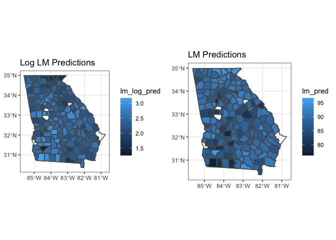

```r
grad_rate_modeling$lm_log_pred = model %>% fitted()
grad_rate_modeling$lm_log_resid = model %>% residuals()
grad_rate_modeling$lm_pred = max(grad_rate_modeling$Graduation_RateH) + 1 - exp(grad_rate_modeling$lm_log_pred)

gridExtra::grid.arrange(
  ggplot() +
    geom_sf(data=grad_rate_modeling, aes(fill=lm_log_pred)) +
    labs(title = "Log LM Predictions") +
    geom_sf(data=init_counties, fill=NA)+
    scale_fill_continuous(na.value="white")
  ,
  ggplot() +
    geom_sf(data=grad_rate_modeling, aes(fill=lm_pred)) +
    labs(title = "LM Predictions") +
    geom_sf(data=init_counties, fill=NA)+
    scale_fill_continuous(na.value="white"),
  ncol=2
)
```

# Frequentist SAR & CAR Model

```r
listW_neigh = nb2listw(listW$neighbours, style = "B")
#eigs = eigenw(listW_neigh)

grad_rate_sar = spautolm(formula = Graduation_RateH_transformed ~ pct_hispanic + pct_white + pct_lep + English_BegH + College_Readiness + PPE,
                         data=grad_rate_modeling,
                         listw = listW_neigh,
                         family = "SAR")
summary(grad_rate_sar)
```

```
##
## Call: spautolm(formula = Graduation_RateH_transformed ~ pct_hispanic +
##     pct_white + pct_lep + English_BegH + College_Readiness +
##     PPE, data = grad_rate_modeling, listw = listW_neigh, family = "SAR")
##
## Residuals:
##       Min        1Q    Median        3Q       Max
## -1.685640 -0.243097  0.044488  0.260555  1.406662
##
## Coefficients:
##                      Estimate  Std. Error z value  Pr(>|z|)
## (Intercept)        4.1336e+00  4.2534e-01  9.7183 < 2.2e-16
## pct_hispanic      -3.9805e-02  1.2587e-02 -3.1625  0.001564
## pct_white         -4.8056e-03  2.0149e-03 -2.3850  0.017080
## pct_lep            5.3667e-02  1.8334e-02  2.9271  0.003421
## English_BegH       9.8358e-03  3.9150e-03  2.5123  0.011994
## College_Readiness -8.4964e-03  3.4680e-03 -2.4500  0.014287
## PPE               -1.0697e-04  2.6083e-05 -4.1013 4.109e-05
##
## Lambda: 0.012694 LR test value: 0.18411 p-value: 0.66786
## Numerical Hessian standard error of lambda: 0.029267
##
## Log likelihood: -99.58169
## ML residual variance (sigma squared): 0.21321, (sigma: 0.46175)
## Number of observations: 154
## Number of parameters estimated: 9
## AIC: 217.16
```

```r
grad_rate_car = spautolm(formula = Graduation_RateH_transformed ~ pct_hispanic + pct_white + pct_lep + English_BegH + College_Readiness + PPE,
                         data=grad_rate_modeling,
                         listw = listW_neigh,
                         family = "CAR")
summary(grad_rate_car)
```

```
##
## Call: spautolm(formula = Graduation_RateH_transformed ~ pct_hispanic +
##     pct_white + pct_lep + English_BegH + College_Readiness +
##     PPE, data = grad_rate_modeling, listw = listW_neigh, family = "CAR")
##
## Residuals:
##       Min        1Q    Median        3Q       Max
## -1.687924 -0.241902  0.054925  0.269958  1.417499
##
## Coefficients:
##                      Estimate  Std. Error z value  Pr(>|z|)
## (Intercept)        4.14232367  0.42502389  9.7461 < 2.2e-16
## pct_hispanic      -0.03982126  0.01257775 -3.1660  0.001545
## pct_white         -0.00484116  0.00201022 -2.4083  0.016028
## pct_lep            0.05364300  0.01831708  2.9286  0.003405
## English_BegH       0.00979224  0.00391393  2.5019  0.012353
## College_Readiness -0.00852540  0.00346619 -2.4596  0.013910
## PPE               -0.00010733  0.00002606 -4.1185 3.813e-05
##
## Lambda: 0.022783 LR test value: 0.16693 p-value: 0.68286
## Numerical Hessian standard error of lambda: 0.054337
##
## Log likelihood: -99.59028
## ML residual variance (sigma squared): 0.21312, (sigma: 0.46165)
## Number of observations: 154
## Number of parameters estimated: 9
## AIC: 217.18
```

## Prediction

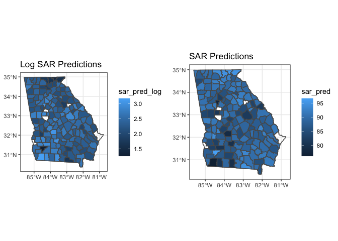

```r
grad_rate_modeling$sar_pred_log = grad_rate_sar$fit$fitted.values
grad_rate_modeling$car_pred_log = grad_rate_car$fit$fitted.values

grad_rate_modeling$sar_pred = max(grad_rate_modeling$Graduation_RateH) + 1 - exp(grad_rate_modeling$sar_pred_log)

grad_rate_modeling$car_pred = max(grad_rate_modeling$Graduation_RateH) + 1 - exp(grad_rate_modeling$car_pred_log)

gridExtra::grid.arrange(
  ggplot() +
    geom_sf(data=init_counties, fill=NA) +
    geom_sf(data=grad_rate_modeling, aes(fill=sar_pred_log)) +
    scale_fill_continuous(na.value="white") +
    labs(title = "Log SAR Predictions"),
   ggplot() +
    geom_sf(data=init_counties, fill=NA) +
    geom_sf(data=grad_rate_modeling, aes(fill=sar_pred)) +
    scale_fill_continuous(na.value="white") +
    labs(title = "SAR Predictions"),
  ncol=2
)
```

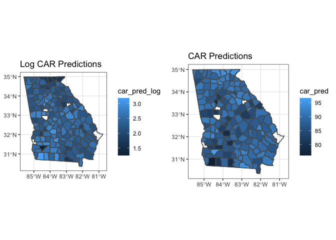

```r
gridExtra::grid.arrange(
  ggplot() +
    geom_sf(data=init_counties, fill=NA) +
    geom_sf(data=grad_rate_modeling, aes(fill=car_pred_log)) +
    scale_fill_continuous(na.value="white") +
    labs(title = "Log CAR Predictions"),
  ggplot() +
    geom_sf(data=init_counties, fill=NA) +
    geom_sf(data=grad_rate_modeling, aes(fill=car_pred)) +
    scale_fill_continuous(na.value="white") +
    labs(title = "CAR Predictions"),
  ncol=2
)
```

## Residuals

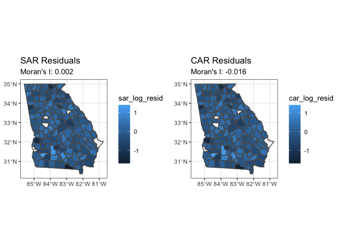

```r
grad_rate_modeling$sar_log_resid = grad_rate_sar$fit$residuals
grad_rate_modeling$car_log_resid = grad_rate_car$fit$residuals

gridExtra::grid.arrange(
  ggplot() +
    geom_sf(data=init_counties, fill=NA) +
    geom_sf(data=grad_rate_modeling, aes(fill=sar_log_resid)) +
    scale_fill_continuous(na.value="white") +
    labs(title = "SAR Residuals",
         subtitle = paste0("Moran's I: ",
                           round(moran.test(grad_rate_modeling$sar_log_resid,
                                            listW_neigh,
                                            na.action = na.exclude)$estimate[1],3))),
  ggplot() +
    geom_sf(data=init_counties, fill=NA) +
    geom_sf(data=grad_rate_modeling, aes(fill=car_log_resid)) +
    scale_fill_continuous(na.value="white") +
    labs(title = "CAR Residuals",
         subtitle = paste0("Moran's I: ",
                           round(moran.test(grad_rate_modeling$car_log_resid,
                                            listW_neigh,
                                            na.action = na.exclude)$estimate[1],3))),
  ncol=2
)
```

# Bayesian CAR Model - Transformed

```r
car_model = "
data {
  int<lower=0> N;
  vector[N] y;
  matrix[N,N] W;
  matrix[N,N] D;
}
parameters {
  vector[N] w_s;
  real beta;
  real<lower=0> sigma2; // variance in CAR part of model
  real<lower=0> sigma2_w; // additional source of error so we get normal model
  real<lower=0,upper=1> phi;
}
transformed parameters {
  vector[N] y_pred = beta + w_s;
}
model {
  matrix[N,N] Sigma_inv = (D - phi * W) / sigma2;
  w_s ~ multi_normal_prec(rep_vector(0,N), Sigma_inv);

  beta ~ normal(0,10);
  sigma2 ~ cauchy(0,5);
  sigma2_w ~ cauchy(0,5);

  y ~ normal(beta+w_s, sigma2_w);
}
"
```

```r
if (!file.exists("stan_car2.rds")) {
  car_fit2 = rstan::stan(
    model_code = car_model,
    data = list(
      N = nrow(grad_rate),
      y = grad_rate$Graduation_RateH_transformed,
      W = W * 1,
      D = diag(rowSums(W))
    ),
    iter = 50000,
    chains = 1,
    thin=50
  )
  saveRDS(car_fit2, "stan_car2.rds")
} else {
  car_fit2 = readRDS("stan_car2.rds")
}
```

## MCMC Diagnostics

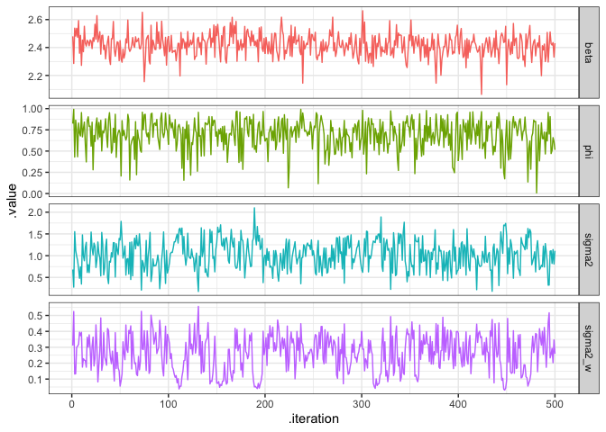

```r
tidybayes::gather_draws(car_fit2, beta, phi, sigma2, sigma2_w) %>%
  ggplot() +
  geom_line(aes(x=.iteration, y=.value, color=.variable)) +
  facet_grid(.variable~., scales = "free_y") +
  guides(color=FALSE)
```

The chains generally look fine. `sigma2` and `sigma2_w` are pretty correlated.

## Prediction & Residuals

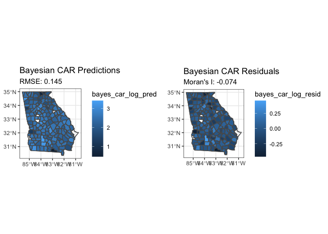

```r
grad_rate_modeling$bayes_car_log_pred = tidybayes::gather_draws(car_fit2, y_pred[i]) %>%
  ungroup() %>%
  group_by(i) %>%
  summarize(
    bayes_car_log_pred = mean(.value)
  ) %>%
  pull(bayes_car_log_pred)

grad_rate_modeling$bayes_car_log_resid = grad_rate_modeling$Graduation_RateH_transformed - grad_rate_modeling$bayes_car_log_pred


gridExtra::grid.arrange(
  ggplot() +
    geom_sf(data=init_counties, fill=NA) +
    geom_sf(data=grad_rate_modeling, aes(fill=bayes_car_log_pred)) +
    scale_fill_continuous(na.value="white") +
    labs(title = "Bayesian CAR Predictions",
         subtitle = paste0("RMSE: ",
                           grad_rate_modeling$bayes_car_log_resid %>%
                             .^2 %>%
                             mean() %>%
                             sqrt() %>%
                             round(3)
         )),
  ggplot() +
    geom_sf(data=init_counties, fill=NA) +
    geom_sf(data=grad_rate_modeling, aes(fill=bayes_car_log_resid)) +
    scale_fill_continuous(na.value="white") +
    labs(title = "Bayesian CAR Residuals",
         subtitle = paste0("Moran's I: ",
                           round(moran.test(grad_rate_modeling$bayes_car_log_resid,
                                            listW_neigh,
                                            na.action = na.exclude)$estimate[1],3)
         )),
  ncol=2
)
```

# Bayesian CAR Model - Transformed & with Betas

```r
car_model_betas = "model{
  for(i in 1:length(y)) {
    y[i] ~ dnorm(mu[i], sigma2_w)
    y_pred[i] ~ dnorm(mu[i], sigma2_w)
    mu[i] = X[i,] %*% beta + omega[i]
  }

  beta[1] ~ dnorm(4,100)

  for(i in 2:7) {
    beta[i] ~ dnorm(0,0.01)
  }

  omega ~ dmnorm(rep(0,length(y)), tau * (D - phi*W))
  sigma2 = 1/tau
  tau ~ dgamma(2, 2)
  sigma2_w ~ dgamma(2, 2)
  phi ~ dunif(0,0.99)
}"
X = matrix(nrow = nrow(grad_rate), ncol = 6)
X[,1] = grad_rate_modeling$pct_hispanic
X[,2] = grad_rate_modeling$pct_white
X[,3] = grad_rate_modeling$pct_lep
X[,4] = grad_rate_modeling$English_BegH
X[,5] = grad_rate_modeling$College_Readiness
X[,6] = grad_rate_modeling$PPE
X = model.matrix(~X)

if (!file.exists("jags_car_betas.rds")) {
  m = rjags::jags.model(
    textConnection(car_model_betas),
    data = list(
      y = grad_rate_modeling$Graduation_RateH_transformed,
      X = X,
      W = W * 1,
      D = diag(rowSums(W))
    )
  )

  update(m, n.iter=25000)

  car_fit_betas = rjags::coda.samples(
    m, variable.names = c("beta", "sigma2", "sigma2_w", "omega", "tau", "phi", "y_pred"),
    n.iter=50000, thin=50
  )
  saveRDS(car_fit_betas, "jags_car_betas.rds")
} else {
  car_fit_betas = readRDS("jags_car_betas.rds")
}
```

## MCMC Diagnostics

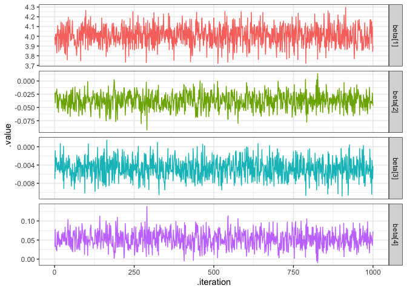

```r
tidybayes::gather_draws(car_fit_betas, beta[i]) %>%
  ungroup() %>%
  filter(i <= 4) %>%
  mutate(.variable = paste0(.variable, "[", i, "]")) %>%
  ggplot(aes(x = .iteration, y = .value, color = .variable)) +
  geom_line() +
  facet_grid(.variable~., scales= "free_y") +
  guides(color=FALSE)
```

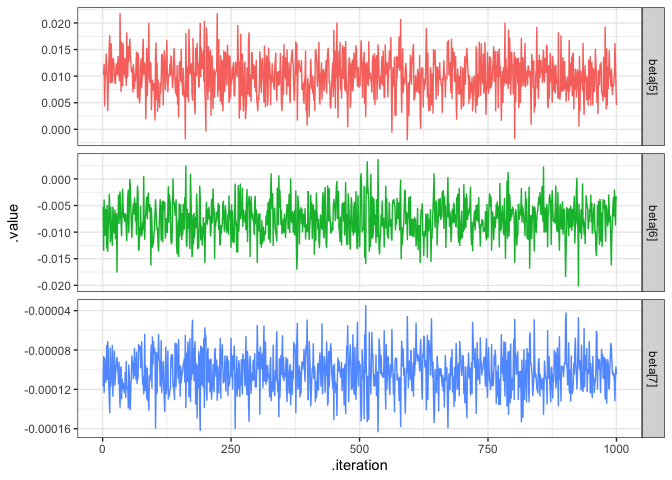

```r
tidybayes::gather_draws(car_fit_betas, beta[i]) %>%
  ungroup() %>%
  filter(i > 4) %>%
  mutate(.variable = paste0(.variable, "[", i, "]")) %>%
  ggplot(aes(x = .iteration, y = .value, color = .variable)) +
  geom_line() +
  facet_grid(.variable~., scales= "free_y") +
  guides(color=FALSE)
```

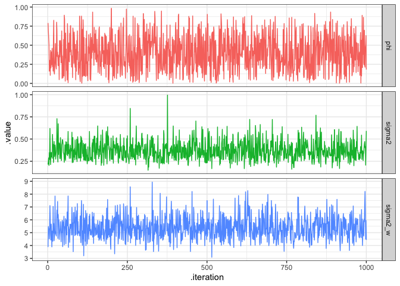

```r
tidybayes::gather_draws(car_fit_betas, sigma2, sigma2_w, phi) %>%
  ungroup() %>%
  ggplot(aes(x = .iteration, y = .value, color = .variable)) +
  geom_line() +
  facet_grid(.variable~., scales= "free_y") +
  guides(color=FALSE)
```

The chains look better than the chains from the previous model.

## Prediction & Residuals

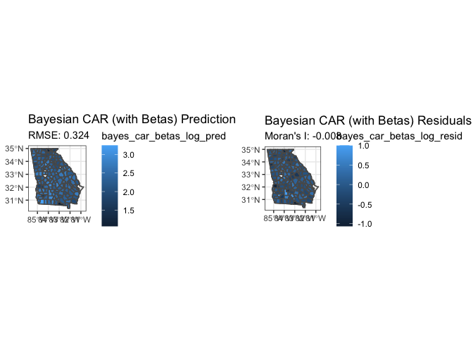

```r
grad_rate_modeling$bayes_car_betas_log_pred = tidybayes::gather_draws(car_fit_betas, y_pred[i]) %>%
  ungroup() %>%
  group_by(i) %>%
  summarise(
    bayes_betas_car_pred = mean(.value)
  ) %>%
  pull(bayes_betas_car_pred)

grad_rate_modeling$bayes_car_betas_log_resid = grad_rate_modeling$Graduation_RateH_transformed - grad_rate_modeling$bayes_car_betas_log_pred

gridExtra::grid.arrange(
  ggplot() +
    geom_sf(data=init_counties, fill=NA) +
    geom_sf(data=grad_rate_modeling, aes(fill=bayes_car_betas_log_pred)) +
    scale_fill_continuous(na.value="white") +
    labs(title = "Bayesian CAR (with Betas) Predictions",
         subtitle = paste0("RMSE: ",
                           grad_rate_modeling$bayes_car_betas_log_resid %>%
                             .^2 %>%
                             mean() %>%
                             sqrt() %>%
                             round(3)
         )),
  ggplot() +
    geom_sf(data=init_counties, fill=NA) +
    geom_sf(data=grad_rate_modeling, aes(fill=bayes_car_betas_log_resid)) +
    scale_fill_continuous(na.value="white") +
    labs(title = "Bayesian CAR (with Betas) Residuals",
         subtitle = paste0("Moran's I: ",
                           round(moran.test(grad_rate_modeling$bayes_car_betas_log_resid,
                                            listW_neigh,
                                            na.action = na.exclude)$estimate[1],3)
         )),
  ncol=2
)
```

# Summary of Models

```r
grad_rate_modeling %>%
  as_data_frame() %>%
  select(ends_with("log_resid")) %>%
  tidyr::gather(model, resid) %>%
  mutate(model = stringr::str_replace(model, "_resid","") %>%
           forcats::as_factor()) %>%
  group_by(model) %>%
  summarize(
    rmse = resid^2 %>% mean(na.rm=TRUE) %>% sqrt(),
    moran = moran.test(resid, listW_neigh, na.action = na.exclude)$estimate[1]
  ) %>%
  arrange(rmse)
```

```
## # A tibble: 5 x 3
##   model                rmse    moran
##   <fct>               <dbl>    <dbl>
## 1 bayes_car_log       0.145 -0.0742
## 2 bayes_car_betas_log 0.324 -0.00843
## 3 car_log             0.462 -0.0165
## 4 sar_log             0.462  0.00173
## 5 lm_log              0.462  0.0178
```